# Preprocessing-cleansing

## Cleansing

- removing variables with high id-ness
- missing values treatment
- recoding values

## ID-ness

- Columns where nearly all values are different
- ID-ness (IDs, Vat numbers,…)

## ID-ness - Python - 1

- calculating ID-ness(unique/nrows)

```python
import pandas as pd
import numpy as np

url='https://raw.githubusercontent.com/urosgodnov/datasets/master/winequality-white.csv'
data = pd.read_csv(url, sep=";")
data["id"]=data.index

data.head(5)
```

```
##    fixed acidity  volatile acidity  citric acid  ...  alcohol  quality  id
## 0            7.0              0.27         0.36  ...      8.8        6   0
## 1            6.3              0.30         0.34  ...      9.5        6   1
## 2            8.1              0.28         0.40  ...     10.1        6   2
## 3            7.2              0.23         0.32  ...      9.9        6   3
## 4            7.2              0.23         0.32  ...      9.9        6   4
##
## [5 rows x 13 columns]
```

## ID-ness - Python - 2

```python
data.nunique()/data.count()
```

```
## fixed acidity           0.013883
## volatile acidity        0.025521
## citric acid             0.017762
## residual sugar          0.063291
## chlorides               0.032666
## free sulfur dioxide     0.026950
## total sulfur dioxide    0.051245
## density                 0.181707
## pH                      0.021029
## sulphates               0.016129
## alcohol                 0.021029
## quality                 0.001429
## id                      1.000000
## dtype: float64
```

```python
data=data[data.columns[data.nunique()/data.count()<=0.9]]
```

## ID-ness - Python - 3

```python
data=data[data.columns[data.nunique()/data.count()<=0.9]]
data.head(3)
```

```
##    fixed acidity  volatile acidity  citric acid  ...  sulphates  alcohol  quality
## 0            7.0              0.27         0.36  ...       0.45      8.8        6
## 1            6.3              0.30         0.34  ...       0.49      9.5        6
## 2            8.1              0.28         0.40  ...       0.44     10.1        6
##
## [3 rows x 12 columns]
```

## Missing values - Python - 1

```python
url='https://raw.githubusercontent.com/urosgodnov/datasets/master/diabetes.csv'
data = pd.read_csv(url)
data.describe()
#Number of missing values
```

```
##        Number_of_times_pregnant  ...  Class_variable
## count                768.000000  ...      768.000000
## mean                   3.845052  ...        0.348958
## std                    3.369578  ...        0.476951
## min                    0.000000  ...        0.000000
## 25%                    1.000000  ...        0.000000
## 50%                    3.000000  ...        0.000000
## 75%                    6.000000  ...        1.000000
## max                   17.000000  ...        1.000000
##
## [8 rows x 9 columns]
```

```python
print((data.iloc[:,1:5] == 0).sum())
```

```
## Plasma_glucose_concentration      5
## Diastolic_blood_pressure         35
## Triceps_skinfold_thickness      227
## 2-Hour_serum_insulin            374
## dtype: int64
```

## Missing values - Python - 2

```python
data.iloc[:,1:5]=data.iloc[:,1:5].replace(0, np.nan)
#Number of missing value
print(data.iloc[:,1:5].isnull().sum())
```

```
## Plasma_glucose_concentration      5
## Diastolic_blood_pressure         35
## Triceps_skinfold_thickness      227
## 2-Hour_serum_insulin            374
## dtype: int64
```

## Missing values - Python - 3

- what to do with missing values?
- a rule of thumb, when the data goes missing on 60–70 percent of the variable, dropping the variable should be considered, though the researches shows this percentage starts at 40 % of missing data
- Schafer ( 1999 ) asserted that a missing rate of 5% or less is inconsequential
- checking the patters of missingnes (MCAR, MAR)

## Missing values - Python - 4

- dropping variables with high percentages of missing values
- mean or median or other summary statistic substitution
- model imputation: using a machine learning algorithm to fix missing values

## Missing values - Python - 5

```python
# of missing data
print(data.iloc[:,1:5].isnull().sum()/data.count())
```

```
## 2-Hour_serum_insulin            0.949239
## Age                                  NaN
## BMI                                  NaN
## Class_variable                       NaN
## Diabetes_pedigree_function           NaN
## Diastolic_blood_pressure        0.047749
## Number_of_times_pregnant             NaN
## Plasma_glucose_concentration    0.006553
## Triceps_skinfold_thickness      0.419593
## dtype: float64
```

```python
data.drop(data.columns[4],axis=1, inplace=True)
data.columns
```

```
## Index(['Number_of_times_pregnant', 'Plasma_glucose_concentration',
##        'Diastolic_blood_pressure', 'Triceps_skinfold_thickness', 'BMI',
##        'Diabetes_pedigree_function', 'Age', 'Class_variable'],
##       dtype='object')
```

## Missing values - Python - 6

```python
#Imputation with mean
meanValue=data["Diastolic_blood_pressure"].mean()
modeValue=data["Number_of_times_pregnant"].mode()
data["Diastolic_blood_pressure"]=data["Diastolic_blood_pressure"].fillna(meanValue)
data["Number_of_times_pregnant"]=data["Number_of_times_pregnant"].fillna(modeValue)
print(data.iloc[:,1:5].isnull().sum()/data.count())
```

```
## Age                                  NaN
## BMI                             0.000000
## Class_variable                       NaN
## Diabetes_pedigree_function           NaN
## Diastolic_blood_pressure        0.000000
## Number_of_times_pregnant             NaN
## Plasma_glucose_concentration    0.006553
## Triceps_skinfold_thickness      0.419593
## dtype: float64
```

## Recoding values - Python - 1

- when granularity of a variable is too high, we should consider merging values/groups

```python
url='https://raw.githubusercontent.com/urosgodnov/datasets/master/winequality-white.csv'
data = pd.read_csv(url, sep=";")
data.quality.value_counts()
```

```
## 6    2198
## 5    1457
## 7     880
## 8     175
## 4     163
## 3      20
## 9       5
## Name: quality, dtype: int64
```

## Recoding values - Python - 2

- lets create different groups 1-5,6,6<
- no case when statement, which is…hm

```python
conditions = [
    (data["quality"].lt(6)),
    (data["quality"].eq(6)),
    (data["quality"].gt(6))]
choices = [1, 2, 3]

data["quality_rc"] = np.select(conditions, choices)
data.quality_rc.value_counts()
```

```
## 2    2198
## 1    1640
## 3    1060
## Name: quality_rc, dtype: int64
```

## Recoding values - Python - 3

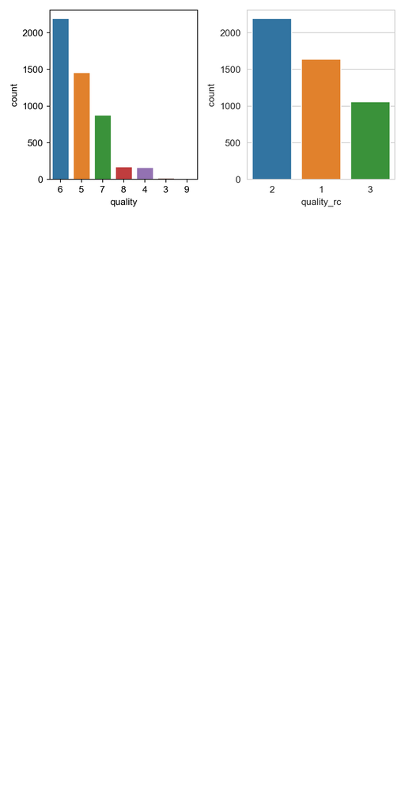

```python
import seaborn as sns
import matplotlib.pyplot as plt
number_of_columns=2
number_of_rows=3
df=data[["quality","quality_rc"]]
df = df.applymap(str)
l=df.columns
plt.figure(figsize=(3*number_of_columns,4*number_of_rows))
for i in range(0,2):
    plt.subplot(number_of_rows + 1,number_of_columns,i+1)
    sns.set_style('whitegrid')
    sns.countplot(x=l[i], data=df)
    plt.tight_layout()
```

## ID-ness - R - 1

- calculating ID-ness(unique/nrows)

```r
library(tidyverse)

url = "https://raw.githubusercontent.com/urosgodnov/datasets/master/winequality-white.csv"
data = read.csv(url, sep = ";")
data <- data %>% mutate(id = row_number())

head(data, 5)
```

```
##   fixed.acidity volatile.acidity citric.acid residual.sugar chlorides
## 1           7.0             0.27        0.36           20.7     0.045
## 2           6.3             0.30        0.34            1.6     0.049
## 3           8.1             0.28        0.40            6.9     0.050
## 4           7.2             0.23        0.32            8.5     0.058
## 5           7.2             0.23        0.32            8.5     0.058
##   free.sulfur.dioxide total.sulfur.dioxide density   pH sulphates alcohol
## 1                  45                  170  1.0010 3.00      0.45     8.8
## 2                  14                  132  0.9940 3.30      0.49     9.5
## 3                  30                   97  0.9951 3.26      0.44    10.1
## 4                  47                  186  0.9956 3.19      0.40     9.9
## 5                  47                  186  0.9956 3.19      0.40     9.9
##   quality id
## 1       6  1
## 2       6  2
## 3       6  3
## 4       6  4
## 5       6  5
```

## ID-ness - R - 2

```r
library(plyr)

sapply(data, n_distinct)/nrow(data)
```

```
##        fixed.acidity     volatile.acidity          citric.acid
##          0.013883218          0.025520621          0.017762352
##       residual.sugar            chlorides  free.sulfur.dioxide
##          0.063291139          0.032666394          0.026949775
## total.sulfur.dioxide              density                   pH
##          0.051245406          0.181706819          0.021028991
##            sulphates              alcohol              quality
##          0.016129032          0.021028991          0.001429155
##                   id
##          1.000000000
```

```r
sapply(data, n_distinct)/nrow(data) < 0.9
```

```
##        fixed.acidity     volatile.acidity          citric.acid
##                 TRUE                 TRUE                 TRUE
##       residual.sugar            chlorides  free.sulfur.dioxide
##                 TRUE                 TRUE                 TRUE
## total.sulfur.dioxide              density                   pH
##                 TRUE                 TRUE                 TRUE
##            sulphates              alcohol              quality
##                 TRUE                 TRUE                 TRUE
##                   id
##                FALSE
```

## ID-ness - R - 3

```r
data <- data[, sapply(data, n_distinct)/nrow(data) < 0.9]
head(data, 3)
```

```
##   fixed.acidity volatile.acidity citric.acid residual.sugar chlorides
## 1           7.0             0.27        0.36           20.7     0.045
## 2           6.3             0.30        0.34            1.6     0.049
## 3           8.1             0.28        0.40            6.9     0.050
##   free.sulfur.dioxide total.sulfur.dioxide density   pH sulphates alcohol
## 1                  45                  170  1.0010 3.00      0.45     8.8
## 2                  14                  132  0.9940 3.30      0.49     9.5
## 3                  30                   97  0.9951 3.26      0.44    10.1
##   quality
## 1       6
## 2       6
## 3       6
```

## Missing values - R - 1

```r
url = "https://raw.githubusercontent.com/urosgodnov/datasets/master/diabetes.csv"
data = read.csv(url)
head(data)
```

```
##   Number_of_times_pregnant Plasma_glucose_concentration
## 1                        6                          148
## 2                        1                           85
## 3                        8                          183
## 4                        1                           89
## 5                        0                          137
## 6                        5                          116
##   Diastolic_blood_pressure Triceps_skinfold_thickness X2.Hour_serum_insulin
## 1                       72                         35                     0
## 2                       66                         29                     0
## 3                       64                          0                     0
## 4                       66                         23                    94
## 5                       40                         35                   168
## 6                       74                          0                     0
##    BMI Diabetes_pedigree_function Age Class_variable
## 1 33.6                      0.627  50              1
## 2 26.6                      0.351  31              0
## 3 23.3                      0.672  32              1
## 4 28.1                      0.167  21              0
## 5 43.1                      2.288  33              1
## 6 25.6                      0.201  30              0
```

```r
# Number of missing values
summary(data[, 1:5] == 0)
```

```
##  Number_of_times_pregnant Plasma_glucose_concentration Diastolic_blood_pressure
##  Mode :logical            Mode :logical                Mode :logical
##  FALSE:657                FALSE:763                    FALSE:733
##  TRUE :111                TRUE :5                      TRUE :35
##  Triceps_skinfold_thickness X2.Hour_serum_insulin
##  Mode :logical              Mode :logical
##  FALSE:541                  FALSE:394
##  TRUE :227                  TRUE :374
```

## Missing values - R - 2

```r
data[, 1:5][data[, 1:5] == 0] <- NA

summary(data)
```

```
##  Number_of_times_pregnant Plasma_glucose_concentration Diastolic_blood_pressure
##  Min.   : 1.000           Min.   : 44.0                Min.   : 24.00
##  1st Qu.: 2.000           1st Qu.: 99.0                1st Qu.: 64.00
##  Median : 4.000           Median :117.0                Median : 72.00
##  Mean   : 4.495           Mean   :121.7                Mean   : 72.41
##  3rd Qu.: 7.000           3rd Qu.:141.0                3rd Qu.: 80.00
##  Max.   :17.000           Max.   :199.0                Max.   :122.00
##  NA's   :111              NA's   :5                    NA's   :35
##  Triceps_skinfold_thickness X2.Hour_serum_insulin      BMI
##  Min.   : 7.00              Min.   : 14.00        Min.   : 0.00
##  1st Qu.:22.00              1st Qu.: 76.25        1st Qu.:27.30
##  Median :29.00              Median :125.00        Median :32.00
##  Mean   :29.15              Mean   :155.55        Mean   :31.99
##  3rd Qu.:36.00              3rd Qu.:190.00        3rd Qu.:36.60
##  Max.   :99.00              Max.   :846.00        Max.   :67.10
##  NA's   :227                NA's   :374
##  Diabetes_pedigree_function      Age        Class_variable
##  Min.   :0.0780             Min.   :21.00   Min.   :0.000
##  1st Qu.:0.2437             1st Qu.:24.00   1st Qu.:0.000
##  Median :0.3725             Median :29.00   Median :0.000
##  Mean   :0.4719             Mean   :33.24   Mean   :0.349
##  3rd Qu.:0.6262             3rd Qu.:41.00   3rd Qu.:1.000
##  Max.   :2.4200             Max.   :81.00   Max.   :1.000
##
```

## Missing values - R - 3

```r
# % of missing data
colSums(is.na(data))/nrow(data) * 100
```

```
##     Number_of_times_pregnant Plasma_glucose_concentration
##                   14.4531250                    0.6510417
##     Diastolic_blood_pressure   Triceps_skinfold_thickness
##                    4.5572917                   29.5572917
##        X2.Hour_serum_insulin                          BMI
##                   48.6979167                    0.0000000
##   Diabetes_pedigree_function                          Age
##                    0.0000000                    0.0000000
##               Class_variable
##                    0.0000000
```

```r
data <- data[, -5]
colnames(data)
```

```
## [1] "Number_of_times_pregnant"     "Plasma_glucose_concentration"
## [3] "Diastolic_blood_pressure"     "Triceps_skinfold_thickness"
## [5] "BMI"                          "Diabetes_pedigree_function"
## [7] "Age"                          "Class_variable"
```

## Missing values - R - 4

- Little’s MCAR test

```r
library(BaylorEdPsych)
result <- LittleMCAR(data)
```

```
## this could take a while
```

```r
result$amount.missing
```

```
##                 Number_of_times_pregnant Plasma_glucose_concentration
## Number Missing               111.0000000                  5.000000000
## Percent Missing                0.1445312                  0.006510417
##                 Diastolic_blood_pressure Triceps_skinfold_thickness BMI
## Number Missing               35.00000000                227.0000000   0
## Percent Missing               0.04557292                  0.2955729   0
##                 Diabetes_pedigree_function Age Class_variable
## Number Missing                           0   0              0
## Percent Missing                          0   0              0
```

```r
paste("p.value=", result$p.value)
```

```
## [1] "p.value= 0"
```

## Missing values - R - 5

-imputation

```r
# Imputation with mean
meanValue = mean(data[, "Diastolic_blood_pressure"], na.rm = TRUE)
maxValue = max(data[, "Number_of_times_pregnant"], na.rm = TRUE)

data[is.na(data$Diastolic_blood_pressure), "Diastolic_blood_pressure"] <- meanValue

data[is.na(data$Number_of_times_pregnant), "Number_of_times_pregnant"] <- maxValue

colSums(is.na(data))/nrow(data) * 100
```

```
##     Number_of_times_pregnant Plasma_glucose_concentration
##                    0.0000000                    0.6510417
##     Diastolic_blood_pressure   Triceps_skinfold_thickness
##                    0.0000000                   29.5572917
##                          BMI   Diabetes_pedigree_function
##                    0.0000000                    0.0000000
##                          Age               Class_variable
##                    0.0000000                    0.0000000
```

## Missing values - R - 6

- using mice package

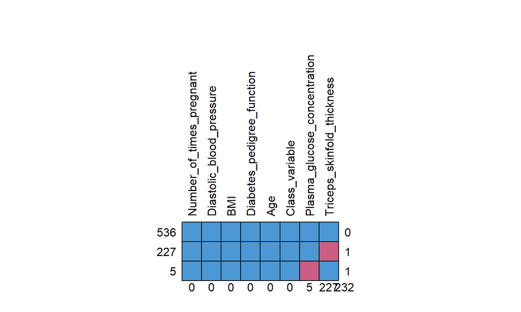

```
##     Number_of_times_pregnant Diastolic_blood_pressure BMI
## 536                        1                        1   1
## 227                        1                        1   1
## 5                          1                        1   1
##                            0                        0   0
##     Diabetes_pedigree_function Age Class_variable Plasma_glucose_concentration
## 536                          1   1              1                            1
## 227                          1   1              1                            1
## 5                            1   1              1                            0
##                              0   0              0                            5
##     Triceps_skinfold_thickness
## 536                          1   0
## 227                          0   1
## 5                            1   1
##                            227 232
```

```r
library(mice)

md.pattern(data, rotate.names = TRUE)
```

## Recoding values - R - 1

- when granularity of a variable is too high, we should consider merging values/groups

```r
url = "https://raw.githubusercontent.com/urosgodnov/datasets/master/winequality-white.csv"
data = read.csv(url, sep = ";")

table(data[, "quality"])
```

```
##
##    3    4    5    6    7    8    9
##   20  163 1457 2198  880  175    5
```

## Recoding values - R - 2

- Recoding in R is very easy as we have case_when

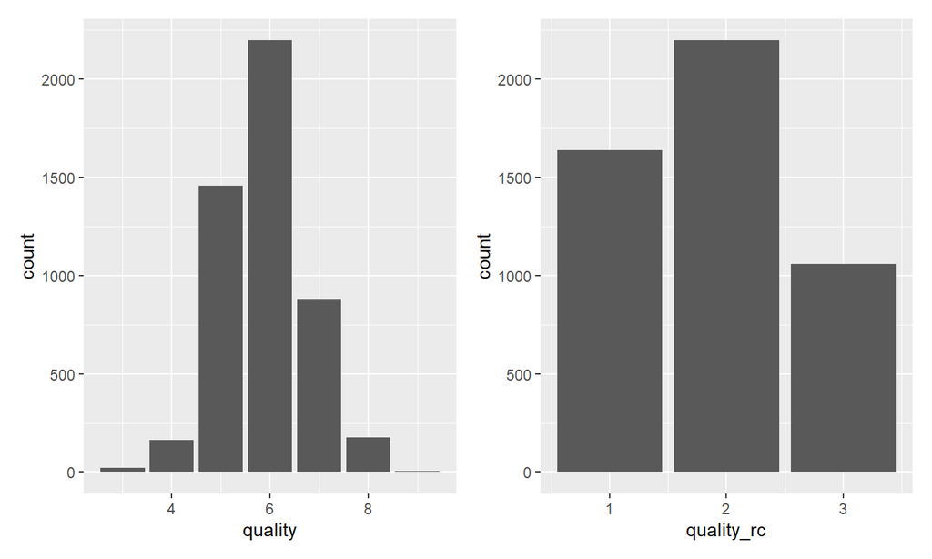

```r
library(patchwork)
data_rc <- data %>% mutate(quality_rc = case_when(quality < 6 ~ 1, quality == 6 ~
    2, TRUE ~ 3))

p1 <- ggplot(data_rc, aes(x = quality)) + geom_bar()

p2 <- ggplot(data_rc, aes(x = quality_rc)) + geom_bar()

p1 | p2
```

## Lab

- use airquality dataset
- perform cleansing steps
- is there something worth to discretize?